# Lab 07 - Permutational Confidence Interval

Nonparametric statistics ay 2021/2022

2021/10/15

*Disclaimer: The present material has been slightly adapted from the original R script prepared by me for the a.y. 2020/2021 Nonparametric statistics course. I hereby assume responsibility for any error that may be present in this document, I do apologise for them and invite you to let me know.*

```r
seed=2781991
B=1000
```

It is relatively computationally intensive, thus we need a bit of “smart” code to do it. This lab would be indeed more complex from a computational point of view than a statistical one.

Let’s simulate some data…

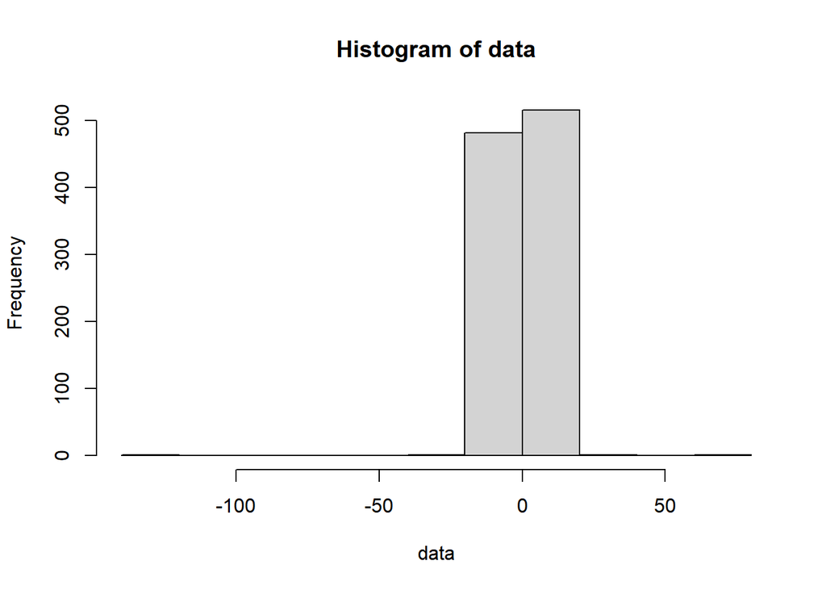

```r
set.seed(seed)
data=stabledist::rstable(1000,1.5,0)
hist(data)
```

```r
median(data)
```

```
## [1] 0.08800729
```

Let’s calculate a confidence interval around the median of this distribution, that is…

```r
median(data)
```

```
## [1] 0.08800729
```

What we need to do is to test over a fine grid of alternative values that contain our true one the alternative hypothesis $H_1:med(X_1) \neq \mu_0$ where $X_1$ is my distribution. To do so I use a 1 population test on symmetric distributions, where my permutation scheme is made of reflections of the data

```r
uni_t_perm=function(data,mu0,B=1000){

data_trans=data-mu0
T0=abs(median(data_trans))
T_perm=numeric(B)
n=length(data)

for(perm in 1:B){

  refl <- rbinom(n, 1, 0.5)*2 - 1
  T_perm[perm]=abs(median(data_trans*refl))

}
return(sum(T_perm>=T0)/B)
}
```

To have a reasonable spatial resolution we need to have a fine grid on which to perform our tests… which means that we need to run A LOT of tests.

```r
grid=seq(-3,3,by=0.001)
length(grid)
```

```
## [1] 6001
```

How to do it quickly on R? Vectorise operations instead of using for cycles. How to do it even faster? Parallelise such vectorised operations!

Let’s read the needed packages

```r
library(pbapply)
library(parallel)
```

Let’s create the cluster and initialise it I need to start by understanding how many (logical…) cores my machine has In my case I have…

```r
detectCores()
```

```
## [1] 16
```

So, let’s create a cluster with 16 cores!

```r
cl=makeCluster(16)
```

I also need to “initialise” my cluster by sending informations that are useful for the computation

```r
clusterExport(cl,varlist=list("data","uni_t_perm"))
```

Now, I need to wrap up my function in a “wrapper” with the required arguments, and then start my parallel calculation!

```r
perm_wrapper=function(grid_point){uni_t_perm(data,grid_point,B=2000)}
pval_function=pbsapply(grid,perm_wrapper,cl=cl)
```

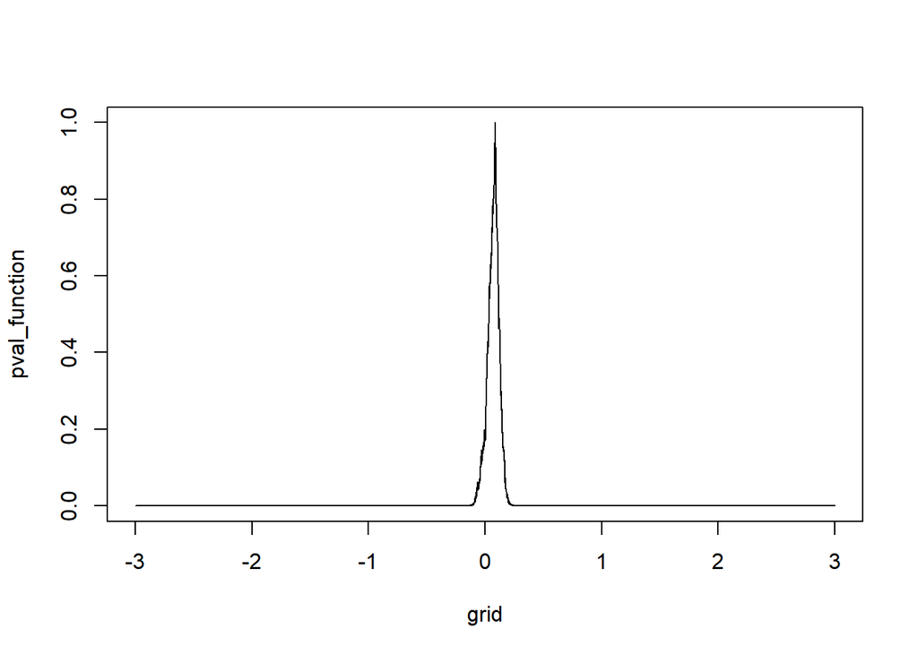

```r
plot(grid,pval_function,type='l')
```

```r
range(grid[pval_function>0.05])
```

```
## [1] -0.065  0.176
```